# Machine learning Project

Abdou K. Allayeh

8/9/2020

# Synopsis

Using devices such as Jawbone Up, Nike FuelBand, and Fitbit it is now possible to collect a large amount of data about personal activity relatively inexpensively. These type of devices are part of the quantified self movement - a group of enthusiasts who take measurements about themselves regularly to improve their health, to find patterns in their behavior, or because they are tech geeks. One thing that people regularly do is quantify how much of a particular activity they do, but they rarely quantify how well they do it.

In this project, we will use data from accelerometers on the belt, forearm, arm, and dumbell of 6 participants. They were asked to perform barbell lifts correctly and incorrectly in 5 different ways.

The data consists of a Training data and a Test data (to be used to validate the selected model).

The goal of your project is to predict the manner in which they did the exercise. This is the “classe” variable in the training set. You may use any of the other variables to predict with.

# Data Processing

## Preparation of libraries and packages

This step for loading some required packages and initializing some variables

```r
install.packages("e1071")
```

```r
library(caret)
library(rpart)
library(rpart.plot)
library(RColorBrewer)
library(randomForest)
library(corrplot)
library(lattice)
library(ggplot2)
library(rattle)
knitr::opts_chunk$set(echo = TRUE)
```

## Download the Data

```r
setwd("~/RDataScience/ML Project")
training_Url <-"https://d396qusza40orc.cloudfront.net/predmachlearn/pml-training.csv"
testing_Url <- "https://d396qusza40orc.cloudfront.net/predmachlearn/pml-testing.csv"
trainFile <- "~/RDataScience/ML Project/data/pml-training.csv"
testFile  <- "~/RDataScience/ML Project/data/pml-testing.csv"
if (!file.exists("./data")) {
  dir.create("./data")
}
if (!file.exists(trainFile)) {
  download.file(training_Url, destfile=trainFile, method="curl")
}
if (!file.exists(testFile)) {
  download.file(testing_Url, destfile=testFile, method="curl")
}
```

## Splitting the Data and Cleaning

Splitting the data into training and testing data. Some basic transformations and cleanup will be performed. We will remove the variables that contains missing values. The pml-training.csv data is used to devise training and testing sets. The pml-test.csv data is used to predict and answer the 20 questions based on the trained model.

```r
training_Raw <- read.csv("./data/pml-training.csv")
testing_Raw <- read.csv("./data/pml-testing.csv")
dim(training_Raw)
```

```
## [1] 19622   160
```

```r
dim(testing_Raw)
```

```
## [1]  20 160
```

```r
set.seed(10)
library(caret)
library(lattice)
library(ggplot2)
samples <- createDataPartition(y=training_Raw$classe, p=0.7, list=F)
ptrain1 <- training_Raw[samples, ]
ptrain2 <- training_Raw[-samples, ]
dim(ptrain1)
```

```
## [1] 13737   160
```

```r
dim(ptrain2)
```

```
## [1] 5885  160
```

## Next: Cleaning Step

1- Remove columns that contains NA 2- Remove variables that are NA 3- Remove the Five variables that have no significant impact on the outcome

```r
nzv <- nearZeroVar(ptrain1)
ptrain1 <- ptrain1[, -nzv]
ptrain2 <- ptrain2[, -nzv]

mostlyNA <- sapply(ptrain1, function(x) mean(is.na(x))) > 0.95
ptrain1 <- ptrain1[, mostlyNA==F]
ptrain2 <- ptrain2[, mostlyNA==F]

ptrain1 <- ptrain1[, -(1:5)]
ptrain2 <- ptrain2[, -(1:5)]
```

```r
dim(ptrain1)
```

```
## [1] 13737    54
```

```r
dim(ptrain2)
```

```
## [1] 5885   54
```

## Note: After this step we are down now to 54 variables

The cleaned training data set contains 13737 observations and 54 variables

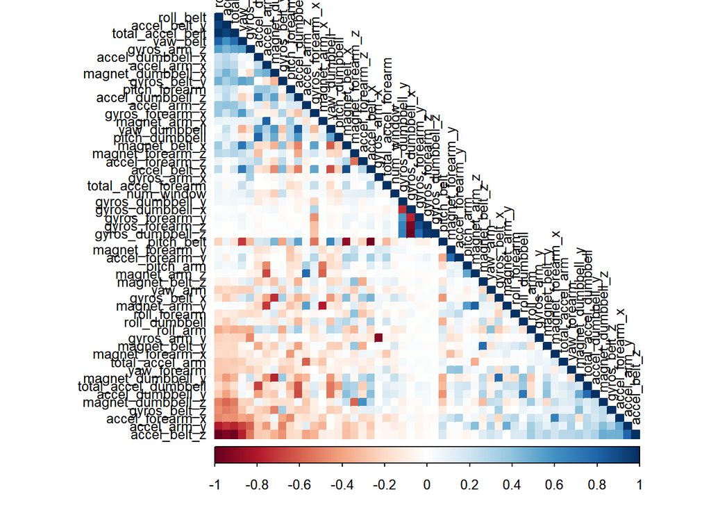

```r
library(corrplot)
cor_mat <- cor(ptrain1[, -54])
corrplot(cor_mat, order = "FPC", method = "color", type = "lower",
         tl.cex = 0.8, tl.col = rgb(0, 0, 0))
```

To obtain the names of the variables we do the following; we use the find Correlation function to search for highly correlated attributes with a cut off equal to 0.70

```r
highlyCorrelated = findCorrelation(cor_mat, cutoff=0.70)
names(ptrain1)[highlyCorrelated]
```

```
##  [1] "accel_belt_z"      "roll_belt"         "accel_belt_y"      "accel_arm_y"
##  [5] "total_accel_belt"  "yaw_belt"          "accel_dumbbell_z"  "accel_belt_x"
##  [9] "pitch_belt"        "magnet_dumbbell_x" "accel_dumbbell_y"  "magnet_dumbbell_y"
## [13] "accel_arm_x"       "accel_dumbbell_x"  "accel_arm_z"       "magnet_arm_y"
## [17] "magnet_belt_z"     "accel_forearm_y"   "gyros_dumbbell_y"  "gyros_forearm_y"
## [21] "gyros_dumbbell_x"  "gyros_dumbbell_z"  "gyros_arm_x"
```

# Model Building

Prediction model: Random forest or decision tree will applied to predict the outcomes

# 1- Random Forest

-Using 3-fold CV to select optimal tuning parameters -Fit model on training data -Print final model to see tuning parameters

```r
library(MASS)
library(caret)
library(randomForest)
rfNews()
fitControl <- trainControl(method="cv", number=3, verboseIter=F)
fit <- train(classe ~ ., data=ptrain1, method="rf", trControl=fitControl)
fit$finalModel
```

```
##
## Call:
##  randomForest(x = x, y = y, mtry = param$mtry)
##                Type of random forest: classification
##                      Number of trees: 500
## No. of variables tried at each split: 27
##
##         OOB estimate of  error rate: 0.22%
## Confusion matrix:
##      A    B    C    D    E  class.error
## A 3904    1    0    0    1 0.0005120328
## B    6 2649    3    0    0 0.0033860045
## C    0    7 2389    0    0 0.0029215359
## D    0    0    6 2245    1 0.0031083481
## E    0    0    0    5 2520 0.0019801980
```

```r
library(caret)
preds <- predict(fit, newdata=ptrain2, call. = FALSE)
```

## Re-training the model

```r
nzv <- nearZeroVar(training_Raw)
training_Raw <- ptrain1[, -nzv]
testing_Raw <- testing_Raw[, -nzv]

mostlyNA <- sapply(ptrain1, function(x) mean(is.na(x))) > 0.95
training_Raw <- ptrain1[, mostlyNA==F]
testing_Raw <- testing_Raw[, mostlyNA==F]

training_Raw <- training_Raw[, -(1:5)]
testing_Raw <- testing_Raw[, -(1:5)]
```

```r
fitControl <- trainControl(method="cv", number=3, verboseIter=F)
fit <- train(classe ~ ., data=training_Raw, method="rf", trControl=fitControl)
```

## Testing or Predict 20 different test cases

```r
Submission <- predict(fit, newdata=testing_Raw)
Submission
```

```
##  [1] B A B A A E D B A A B C B A E E A B B B
## Levels: A B C D E
```

# 2- Decision Tree Model

```r
library(rpart)
library(rpart.plot)
library(RColorBrewer)
library(rattle)
library(MASS)
library(caret)
```

## Cross Validation

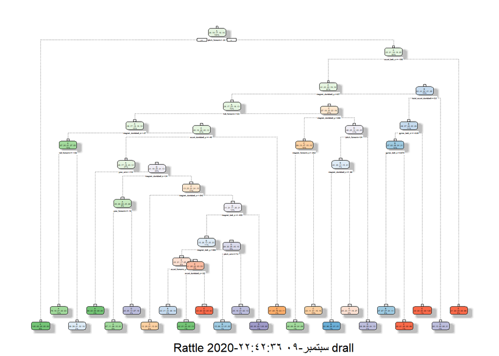

```r
subSamples <- createDataPartition(y=training_Raw$classe, p=0.70, list=FALSE)
subTraining <- training_Raw[subSamples, ]
subTesting <- training_Raw[-subSamples, ]

FitDT <- rpart(classe ~ ., data=subTraining, method="class")
fancyRpartPlot(FitDT)
```

[figure not shown]

```r
predictTreeMod1 <- predict(FitDT, subTesting, type = "class")
rpart.plot(modFitDT, main="Classification Tree", extra=102, under=TRUE, faclen=0)
```

# General Conclusion